# Классификация самолётов

Есть много разных самолётов. Модели могут быть новыми или старыми, быть предназначенными для коротких или, наоборот, очень длинных перелётов. Было бы интересно попробовать по параметрам самолёта определить его модель.

Для этого можно воспользоваться алгоритмом kNN. Это алгоритм, который позволяет классифицировать точку, основываясь на классах её $k$ ближайших соседей.

Соседи определяются как ближайшие точки по какой-нибудь метрике дистанции (например, Евклидовой метрике) в пространстве признаков. Признаки, само собой, нужно отнормировать (достаточно к единичной дисперсии, но каноничнее ещё и к нулевому среднему), чтобы признак с большой выборочной дисперсией не имел слишком большой вес в метрике дистанции.

Только каким должен быть $k$? Слишком маленьким не хочется - модель будет слишком чувствительна к маленьким случайным вкраплениям одного класса среди множества точек другого. Слишком большое значение - тоже плохо: модель будет слишком чувствительна к удалённым точкам.

Есть несколько способов обоснованно выбрать $k$ - например, методом кросс-валидации. Есть много вариаций кросс-валидации, из которых я выбрал k-fold cross-validation (здесь k не связано с параметром модели kNN). Берётся како-то значение параметра $k$ в kNN. От всех точек берётся 80%, которые будут training sample, а оставшиеся 20% - testing sample. На testing sample считается метрика качества (точность классификации). Процесс повторяется 5 раз (в итоге каждая точка ровно 1 раз будет в testing sample). Берётся среднее от метрики качества. Так делается для некоторого набора значений $k$, и у какого значения качество лучше - то и оптимальное.

Сначала приведём данные в порядок. Прочитаем файл, удалим битые строки и вытащим возраст судна из даты его первого полёта.

```r
df = read.csv("knn_data.csv", sep=';')
df = df[df$first_flight_date != "", ]
for (i in 1:nrow(df)) {

  y = strtoi(substr(df$first_flight_date[i], 1, 4))

  m = substr(df$first_flight_date[i], 6, 7)
  if (substr(m, 1, 1) == "0") {
    m = substr(m, 2, 2)
  }
  m = strtoi(m)

  d = substr(df$first_flight_date[i], 9, 10)
  if (substr(d, 1, 1) == "0") {
    d = substr(d, 2, 2)
  }
  d = strtoi(d)

  age <- (2021 - y) * 365 + (6 - m) * 30 + (8 - d)

  df$age_d[i] = age
}

sort(table(df$iata_type), decreasing = TRUE)
```

```
     B737-800      A320-200      A319-100      B737-700      A321-200      B777-300      B777-200      B757-200      A330-300      B767-300      A330-200      B737-900      B747-400      A380-800   CL-600-2B19
         2601          2578           980           821           758           480           472           470           460           436           393           294           235           166           162
   EMB190-100        B787-8        ERJ145     A300-600F         MD-11         MD-88      A340-300        B747-8    EMB170-200      B737-300   CL-600-2D24     A300-600R      A340-600      B757-300   CL-600-2C10
          161           158           125           103            95            77            75            67            67            63            59            58            57            53            53
     A321-100         MD-90      A318-100     ATR72-500      B717-200      B767-400      B767-200       DC-9-83      B737-400      B737-600      B737-200     ATR72-600      A310-300        ERJ140      DC-10-10
           50            44            39            37            37            37            34            34            31            30            29            26            24            23            22
        ARJ85    EMB170-100     ATR72-200       SSJ 100     ATR42-300      DC-10-30    F28 MK0100      B737-500    EMB190-200   CL-600-2D15      B747-200        S340 B      B727-100        EMB120      B727-200
           21            21            20            20            19            19            18            17            16            15            14            14            13            10             9
       B787-9        A300B4        ARJ100      B707-300     DHC-8-300      A300-600      A350-900        An-148       DC-9-30     DHC-8-100     DHC-8-400         Il-62      B720-100       DC-9-82   CL-600-2E25
            8             7             7             7             7             6             6             6             6             5             5             5             4             4             3
   F28 MK1000        S340 A    Tu-204-100      A310-200      A340-500        An-124     F28 MK070    F28 MK3000 L1011-Tristar     B.146-300      B747-100       DC-8-50     DHC-8-200        ERJ135    F28 MK4000
            3             3             3             2             2             2             2             2             2             1             1             1             1             1             1
       Tu-154    Tu-204-300
            1             1
```

[output not shown]

[output cut: 990 more lines]

Как выглядят данные?

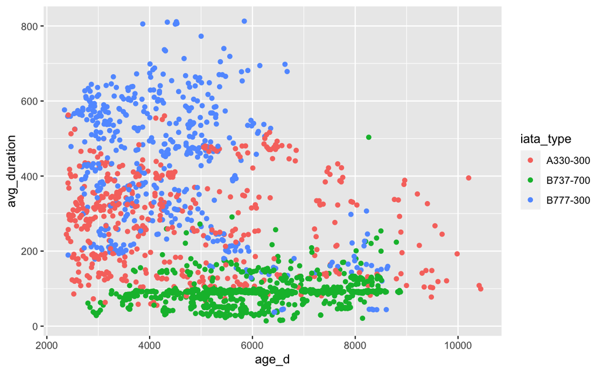

Это хороший сеттинг для kNN: с одной стороны, есть различимые кластеры, поэтому алгоритм сможет обеспечить адекватную точность; с другой стороны, нет четких границ этих кластеров, поэтому задача не кажется слишком простой.

Напишем функцию для рандомного распределения выборки на разные группы кросс-валидации.

|  | X | icao_code_hex | iata_type | first_flight_date | avg_duration | age_d | group |
| --- | --- | --- | --- | --- | --- | --- | --- |
| 2 | 13 | 4A09A1 | B737-700 | 2002-12-19T23:00:00+00:00 | 153.57143 | 6744 | 3 |
| 82 | 198 | 7809EF | A330-300 | 2013-03-11T23:00:00+00:00 | 334.37084 | 3007 | 1 |
| 83 | 199 | 780B69 | A330-300 | 2013-07-01T22:00:00+00:00 | 356.08179 | 2897 | 4 |
| 84 | 200 | 780C2F | A330-300 | 2014-05-04T22:00:00+00:00 | 307.90130 | 2589 | 3 |
| 166 | 303 | 151D2C | B737-700 | 2000-12-04T23:00:00+00:00 | 140.24762 | 7489 | 5 |
| 295 | 545 | 7582E3 | A330-300 | 2013-05-14T22:00:00+00:00 | 189.29669 | 2944 | 5 |
| 296 | 546 | 7582E4 | A330-300 | 2013-07-29T22:00:00+00:00 | 156.48456 | 2869 | 1 |
| 297 | 547 | 758328 | A330-300 | 2014-01-29T23:00:00+00:00 | 202.87097 | 2684 | 4 |
| 298 | 548 | 758329 | A330-300 | 2014-04-17T22:00:00+00:00 | 179.69970 | 2606 | 1 |
| 299 | 549 | 75832A | A330-300 | 2014-07-16T22:00:00+00:00 | 184.28547 | 2517 | 3 |

[output cut: 990 more lines]

Напишем функцию для нормирования выборки (нормировать будем на основе статистических параметров training set).

[output not shown]

[output cut: 990 more lines]

Напишем функцию, классифицирующую точку по её соседям.

```r
dist_matrix = as.matrix(dist(normalize_data(df1, 0)[c("age_d", "avg_duration")], diag=TRUE, upper=TRUE))

classify <- function(x, k, g) {
  predicted = rep(0, nrow(x[x$group == g,]))
  for (i in 1:nrow(x[x$group == g,])) {
    d = dist_matrix[i,]
    d[x$group == g] = 10000
    ix = sort(d, index.return=TRUE)$ix[1:k]
    types = x[ix,]$iata_type
    t = sort(table(types), decreasing=TRUE)
    if (length(t) == 1) {
      predicted[i] = names(t[1])
    }
    else if (t[1] > t[2]) {
      predicted[i] = names(t[1])
    }
    else if (length(t) == 2) {
      r = runif(1, min=1, max=2)
      predicted[i] = names(t[r])
    }
    else if (t[2] > t[3]) {
      r = runif(1, min=1, max=2)
      predicted[i] = names(t[r])
    }
    else {
      r = runif(1, min=1, max=3)
      predicted[i] = names(t[r])
    }
  }
  return(predicted)
}
```

Напишем функцию, оценивающую точность классификации для какого-то $k$.

```r
accuracy <- function(x, k) {
  correct <- rep(0, 5)
  for (group in 1:5) {
    actual = x[x$group == group,]$iata_type
    predicted = classify(normalize_data(df1, group), k, group)
    correct[group] = sum(actual == predicted)
  }
  return(sum(correct) / nrow(x))
}
```

Посчитаем метрику точности модели для $k$ от 1 до 200 (200 - это много, считаться будет долго).

```r
goodness = rep(0, 200)
for (k in 1:200) {
  goodness[k] = accuracy(df1, k)
}
```

Построим график зависимости качества классификации от значения параметра $k$.

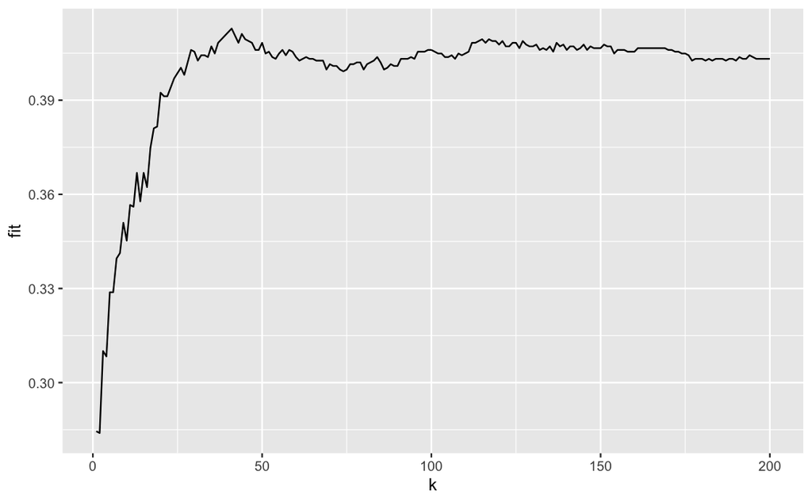

Видно, что поначалу точность модели растёт вместо со сложностью: чем больше точек принимается в расчёт, тем лучше предсказательная сила. Но со временем наступает некая стагнация: далёкие точки несут мало ценности в плане точности, поэтому точность фиксируется около 40%. Оптимальным кажется значение $k=41$: оно и дает хорошую точность, и не выглядит неадекватно большим.

Построим разбиение пространства признаков на три класса при $k=41$. Для наглядности 20% выборки сделаем test set.

```r
library(ggiraph)

age_d = df1[df1$group == 1, ]$age_d
duration = df1[df1$group == 1, ]$avg_duration
iata_type = df1[df1$group == 1, ]$iata_type
icao_code_hex = df1[df1$group == 1, ]$icao_code_hex
iata_type_pr = classify(normalize_data(df1, 1), 41, 1)
df_plot = data.frame(age_d=age_d, duration=duration, iata_type_pr=iata_type_pr, iata_type=iata_type, icao_code_hex=icao_code_hex)

get_hull = function(x) {
  return(x[chull(x$age_d, x$duration), ])
}

bounds = ddply(df_plot, .fun=get_hull, .variables='iata_type_pr')
gg = ggplot(df_plot, aes(age_d, duration, color=iata_type_pr, fill=iata_type_pr)) + geom_polygon(data=bounds, aes(age_d, duration), alpha=0.1) + geom_point_interactive(size=3, tooltip=iata_type, data_id=icao_code_hex) + theme_minimal()
girafe(ggobj=gg)
```

[interactive chart not shown]

Полигоны обозначают области, в которых содержатся точки с какой-то предсказанной моделью самолёта. Например, в зеленой области содержатся все точки, про которые модель сказала, что они соответствуют Boeing 737. Хотя предсказание может быть неточным: при наведении на точку будет показана истинная модель самолёта. На графике видно, что кластеры сильно пересекаются, что объясняет невысокую метрику качества модели.

Здесь использовано несколько слоёв графика (базовый фон, точки и многоугольники), а также ggplot2 extension под названием ggiraph. Не забудь всё это отметить при грейдинге :)